# Майнор "Интеллектуальный анализ данных"

# Курс "Введение в анализ данных"

# Лабораторная работа №1. Обработка и первичный анализ данных

# Выполнил: Бараненков С.С 18ПИ-2

### Инициализируем значения

```python
import pandas as pd
import numpy as np
from seaborn import heatmap
from matplotlib import rc
import matplotlib.pyplot as plt
from collections import defaultdict
from warnings import filterwarnings

filterwarnings('ignore')

pd.set_option('display.max_columns', 40)
pd.set_option('display.max_colwidth', None)
```

```python
data = pd.read_csv("students_data.csv")
features = pd.read_csv('students_data_features.csv', delimiter=';', encoding='windows-1251')
```

### Задание 1

- Для каждого признака определите, к какому типу он относится.
- Проверьте значения признаков на наличие опечаток и ошибок, исправьте их.  
  **Note:** Исправлять ошибки нужно программно, модифицировать руками исходный файл нельзя.
- При необходимости, приведите признак к определенному вами типу.

```python
num = 'числовой'
discr = ' дискретный'
unlim = ' непрерывный'
cat = 'категориальный'
ordered = ' упорядоченный'
nom = ' номинальный'
b = 'булевый (категориальный)'
features.loc[features['Признак'].isin(['ID','age','absences']), 'Типы'] = num+unlim
features.loc[features['Признак'].isin(['Pstatus','address', 'sex', 'school', 'Subject']), 'Типы'] = cat+nom
features.loc[10:13, 'Типы'] = cat+nom
features.loc[17:24, 'Типы'] = b
features.loc[features['Признак'] == 'cheating', 'Типы'] = b
features.loc[features['Признак'].isin(['studytime','Medu','Fedu','traveltime', 'famsize']), 'Типы'] = cat+ordered
features.loc[25:30, 'Типы'] = cat+ordered
features.loc[features['Признак'] == 'failures', 'Типы'] = num + discr
features.loc[33:,'Типы'] = num + discr
features[['Признак', 'Типы']]
```

|  | Признак | Типы |
| --- | --- | --- |
| 0 | ID | числовой непрерывный |
| 1 | Subject | категориальный номинальный |
| 2 | school | категориальный номинальный |
| 3 | sex | категориальный номинальный |
| 4 | age | числовой непрерывный |
| 5 | address | категориальный номинальный |
| 6 | famsize | категориальный упорядоченный |
| 7 | Pstatus | категориальный номинальный |
| 8 | Medu | категориальный упорядоченный |
| 9 | Fedu | категориальный упорядоченный |
| 10 | Mjob | категориальный номинальный |
| 11 | Fjob | категориальный номинальный |
| 12 | reason | категориальный номинальный |
| 13 | guardian | категориальный номинальный |
| 14 | traveltime | категориальный упорядоченный |
| 15 | studytime | категориальный упорядоченный |
| 16 | failures | числовой дискретный |
| 17 | schoolsup | булевый (категориальный) |
| 18 | famsup | булевый (категориальный) |
| 19 | paid | булевый (категориальный) |
| 20 | activities | булевый (категориальный) |
| 21 | nursery | булевый (категориальный) |
| 22 | higher | булевый (категориальный) |
| 23 | internet | булевый (категориальный) |
| 24 | romantic | булевый (категориальный) |
| 25 | famrel | категориальный упорядоченный |
| 26 | freetime | категориальный упорядоченный |
| 27 | goout | категориальный упорядоченный |
| 28 | Dalc | категориальный упорядоченный |
| 29 | Walc | категориальный упорядоченный |
| 30 | health | категориальный упорядоченный |
| 31 | absences | числовой непрерывный |
| 32 | cheating | булевый (категориальный) |
| 33 | G1 | числовой дискретный |
| 34 | G2 | числовой дискретный |
| 35 | G3 | числовой дискретный |

# Только после выполнения задания до меня дошло, что можно было посмотреть список значений вот так :(

```python
for column in data.columns:
    print(data[column].unique())
```

```
[100097 101021 102965 ... 998425 999143 999194]
['Por' 'Math']
['GP' 'MS']
['F' 'M' 'm']
[16 17 18 15 19 21 20 22]
['U' 'R']
['GT3' 'LE3']
['A' 'T' 't']
['3' '1' '2' '4' '0' 'o']
['4' '2' '3' '1' 'o' '0']
['services' 'other' 'health' 'at_home' 'teacher' 'at-home']
['other' 'services' 'health' 'at-home' 'teacher' 'at_home']
['course' 'home' 'reputation' 'other']
['father' 'mother' 'other' 'futher']
[1 2 3 4]
[1 2 4 3]
[0 2 1 3]
['no' 'yes']
['no' 'yes']
['no' 'yes']
['no' 'yes']
['yes' 'no']
['yes' 'no']
['yes' 'no']
['no' nan 'yes']
[ 3.  5.  4.  1.  2. nan]
[2 3 4 1 5]
[1 4 5 3 2]
[ 1.  3.  4.  2.  5. nan]
[ 4.  3.  5.  1.  2. nan]
[5 3 4 2 1]
[12  2  0  4  6 10  7 20 14 11 24  8 16 21  1 18  5 22  9  3 15 26 25 54
 56 40 19 13 38 30 17 28 32 23 75]
[nan 'yes' 'no']
[15 17  9 14 12 11 13  7 16  6  8 10 18  0  5  3  4 19]
[13 18  8 15 11 12 14  6 10 16  5  7  9 17  0  4 19]
[14 17 10 16 13 12  9  6 11  8 18 15  0  5  7 19  4  1 20]
```

```python
data[~data['ID'].apply(lambda x: np.isreal(x))]
#ошибок не обнаружено
```

|  | ID | Subject | school | sex | age | address | famsize | Pstatus | Medu | Fedu | Mjob | Fjob | reason | guardian | traveltime | studytime | failures | schoolsup | famsup | paid | activities | nursery | higher | internet | romantic | famrel | freetime | goout | Dalc | … |
| --- | --- | --- | --- | --- | --- | --- | --- | --- | --- | --- | --- | --- | --- | --- | --- | --- | --- | --- | --- | --- | --- | --- | --- | --- | --- | --- | --- | --- | --- | --- |

```python
data[~data['Subject'].isin(['Math','Por'])]
#ошибок не обнаружено

# приведем к кадегориальному типу
data['Subject'] = pd.Categorical(data['Subject'], ordered = False)
```

```python
data[~data['school'].isin(['GP','MS'])]
#ошибок не обнаружено

# приведем к кадегориальному типу
data['school'] = pd.Categorical(data['school'], ordered = False)
```

```python
data[~data['sex'].isin(['F','M'])]
#ошибка с некапитализированными символами m!
data.loc[data['sex']=='m', 'sex'] = 'M'

# приведем к кадегориальному типу
data['sex'] = pd.Categorical(data['sex'], ordered = False)
```

```python
data[~data['age'].apply(lambda x: np.isreal(x))]
#ошибок не обнаружено
```

|  | ID | Subject | school | sex | age | address | famsize | Pstatus | Medu | Fedu | Mjob | Fjob | reason | guardian | traveltime | studytime | failures | schoolsup | famsup | paid | activities | nursery | higher | internet | romantic | famrel | freetime | goout | Dalc | … |
| --- | --- | --- | --- | --- | --- | --- | --- | --- | --- | --- | --- | --- | --- | --- | --- | --- | --- | --- | --- | --- | --- | --- | --- | --- | --- | --- | --- | --- | --- | --- |

```python
data[~data['address'].isin(['U','R'])]
#ошибок не обнаружено

# приведем к кадегориальному типу
data['address'] = pd.Categorical(data['address'], ordered = False)
```

```python
data[~data['famsize'].isin(['LE3','GT3'])]
#ошибок не обнаружено


# приведем к кадегориальному типу
data['famsize'] = pd.Categorical(data['famsize'], ordered = False)
```

```python
data[~data['Pstatus'].isin(['T','A'])]
#ошибка с некапитализированными символами t!
data.loc[data['Pstatus']=='t', 'Pstatus'] = 'T'

# приведем к кадегориальному типу
data['Pstatus'] = pd.Categorical(data['Pstatus'], ordered = False)
```

```python
data[~data['Medu'].isin([str(i) for i in range(0,5)])]
#ошибка с заменой 0 на o!
data.loc[data['Medu'] == 'o','Medu'] = '0'

# приведем к кадегориальному типу
data['Medu'] = pd.Categorical(data['Medu'], ordered = True)
```

```python
data[~data['Fedu'].isin([str(i) for i in range(0,5)])]
#ошибка с заменой 0 на o!
data.loc[data['Fedu'] == 'o','Fedu'] = '0'

# приведем к кадегориальному типу
data['Fedu'] = pd.Categorical(data['Fedu'], ordered = True)
```

```python
data[~data['Mjob'].isin(['teacher', 'health', 'services', 'at_home', 'other'])]
#ошибка с заменой at_home на at-home!
data.loc[data['Mjob'] == 'at-home','Mjob'] = 'at_home'

# приведем к кадегориальному типу
data['Mjob'] = pd.Categorical(data['Mjob'], ordered = False)
```

```python
data[~data['Fjob'].isin(['teacher', 'health', 'services', 'at_home', 'other'])]
#ошибка с заменой at_home на at-home!
#исправим
data.loc[data['Fjob'] == 'at-home','Fjob'] = 'at_home'

# приведем к кадегориальному типу
data['Fjob'] = pd.Categorical(data['Fjob'], ordered = False)
```

```python
data[~data['reason'].isin(['home', 'reputation', 'course', 'other'])]
#ошибок не обнаружено


# приведем к кадегориальному типу
data['reason'] = pd.Categorical(data['reason'], ordered = False)
```

```python
data[~data['guardian'].isin(['mother', 'father', 'other'])]
#ошибка с заменой father на futher!
data.loc[data['guardian'] == 'futher','guardian'] = 'father'

# приведем к кадегориальному типу
data['guardian'] = pd.Categorical(data['guardian'], ordered = False)
```

```python
data[~data['studytime'].isin(range(1,5))]
#ошибок не обнаружено

# приведем к кадегориальному типу
data['studytime'] = pd.Categorical(data['studytime'], ordered = True)
```

```python
data[~data['traveltime'].isin(range(1,5))]
#ошибок не обнаружено

# приведем к кадегориальному типу
data['traveltime'] = pd.Categorical(data['traveltime'], ordered = True)
```

```python
data[~data['failures'].isin([0, 1, 2, 4])]
data.loc[~data['failures'].isin([0, 1, 2, 4]), 'failures'] = 4
#найдены значения вне допустимых, заменим на 4
```

```python
data[~data['schoolsup'].isin(['no', 'yes'])]
#ошибок не обнаружено

# Меняем yes и no на булевые эквиваленты
data['schoolsup'].replace({'yes': True, 'no': False}, inplace = True)

# приведем к булевому типу
data['schoolsup'] = data['schoolsup'].astype('bool')
```

```python
data[~data['famsup'].isin(['no', 'yes'])]
#ошибок не обнаружено

# Меняем yes и no на булевые эквиваленты
data['famsup'].replace({'yes': True, 'no': False}, inplace = True)

# приведем к булевому типу
data['famsup'] = data['famsup'].astype('bool')
```

```python
data[~data['paid'].isin(['no, yes'])]
#ошибок не обнаружено

# Меняем yes и no на булевые эквиваленты
data['paid'].replace({'yes': True, 'no': False}, inplace = True)

# приведем к булевому типу
data['paid'] = data['paid'].astype('bool')
```

```python
data[~data['activities'].isin(['no, yes'])]
#ошибок не обнаружено

# Меняем yes и no на булевые эквиваленты
data['activities'].replace({'yes': True, 'no': False}, inplace = True)

# приведем к булевому типу
data['activities'] = data['activities'].astype('bool')
```

```python
data[~data['nursery'].isin(['no, yes'])]
#ошибок не обнаружено

# Меняем yes и no на булевые эквиваленты
data['nursery'].replace({'yes': True, 'no': False}, inplace = True)

# приведем к булевому типу
data['nursery'] = data['nursery'].astype('bool')
```

```python
data[~data['higher'].isin(['no, yes'])]
#ошибок не обнаружено

# Меняем yes и no на булевые эквиваленты
data['higher'].replace({'yes': True, 'no': False}, inplace = True)

# приведем к булевому типу
data['higher'] = data['higher'].astype('bool')
```

```python
data[~data['internet'].isin(['no, yes'])]
#ошибок не обнаружено

# Меняем yes и no на булевые эквиваленты
data['internet'].replace({'yes': True, 'no': False}, inplace = True)

# приведем к булевому типу
data['internet'] = data['internet'].astype('bool')
```

```python
data[~data['romantic'].isin(['no, yes'])]
#ошибок не обнаружено

# приведем к булевому типу
data['romantic'].replace({'yes': True, 'no': False}, inplace = True)
#data['romantic'] = data['romantic'].astype('bool')
#обнаружены NaN, исправим в следующем задании
```

```python
data[~data['famrel'].isin(range(1,6))]
#обнаружены NaN, исправим в следующем задании

#data['famrel'] = data['famrel'].astype('category')
```

|  | ID | Subject | school | sex | age | address | famsize | Pstatus | Medu | Fedu | Mjob | Fjob | reason | guardian | traveltime | studytime | failures | schoolsup | famsup | paid | activities | nursery | higher | internet | romantic | famrel | freetime | goout | Dalc | … |
| --- | --- | --- | --- | --- | --- | --- | --- | --- | --- | --- | --- | --- | --- | --- | --- | --- | --- | --- | --- | --- | --- | --- | --- | --- | --- | --- | --- | --- | --- | --- |
| 85 | 164833 | Por | GP | F | 16 | U | GT3 | T | 2 | 2 | services | other | reputation | mother | 2 | 2 | 0 | False | False | False | True | False | True | True | False | NaN | 4 | 4 | 1.0 | … |
| 116 | 189712 | Math | GP | M | 16 | U | LE3 | A | 3 | 4 | services | other | home | mother | 1 | 2 | 0 | True | True | False | True | True | True | True | False | NaN | 3 | 3 | 1.0 | … |
| 146 | 212614 | Math | GP | F | 19 | U | LE3 | T | 1 | 1 | at_home | other | reputation | other | 1 | 2 | 1 | True | True | False | True | False | True | True | False | NaN | 4 | 3 | 1.0 | … |
| 159 | 224690 | Por | GP | M | 17 | U | LE3 | T | 2 | 3 | services | services | reputation | father | 1 | 2 | 0 | False | True | False | False | False | True | True | False | NaN | 3 | 3 | 1.0 | … |
| 398 | 434990 | Por | GP | M | 16 | U | GT3 | T | 4 | 4 | health | other | course | mother | 1 | 1 | 0 | False | True | False | True | True | True | True | False | NaN | 4 | 4 | 1.0 | … |
| 434 | 469435 | Math | MS | M | 19 | R | GT3 | T | 1 | 1 | other | other | home | other | 3 | 1 | 1 | False | True | False | False | True | True | True | False | NaN | 4 | 4 | 3.0 | … |
| 455 | 486246 | Por | GP | F | 15 | U | GT3 | T | 4 | 4 | services | teacher | other | father | 1 | 2 | 0 | True | True | False | True | False | True | True | False | NaN | 4 | 4 | 1.0 | … |
| 478 | 504919 | Por | GP | F | 19 | U | LE3 | A | 2 | 3 | at_home | other | home | other | 2 | 1 | 1 | False | False | False | False | True | False | True | False | NaN | 2 | 3 | 3.0 | … |
| 602 | 624719 | Por | GP | M | 18 | R | LE3 | T | 3 | 2 | services | other | reputation | mother | 2 | 3 | 0 | False | True | False | True | True | True | True | False | NaN | 4 | 2 | 1.0 | … |
| 820 | 807503 | Math | GP | M | 15 | U | GT3 | T | 4 | 3 | teacher | other | reputation | mother | 1 | 2 | 0 | False | False | False | False | True | True | True | False | NaN | 4 | 1 | 1.0 | … |

```python
data[~data['freetime'].isin(range(1,6))]
#ошибок не обнаружено

# приведем к кадегориальному типу
data['freetime'] = pd.Categorical(data['freetime'], ordered = True)
```

```python
data[~data['goout'].isin(range(1,6))]
data['goout'] = pd.Categorical(data['goout'], ordered = True)
#ошибок не обнаружено
```

```python
data[~data['Dalc'].isin(range(1,6))]
#data['Dalc'] = data['Dalc'].astype('category')
#обнаружены NaN, исправим в следующем задании
```

|  | ID | Subject | school | sex | age | address | famsize | Pstatus | Medu | Fedu | Mjob | Fjob | reason | guardian | traveltime | studytime | failures | schoolsup | famsup | paid | activities | nursery | higher | internet | romantic | famrel | freetime | goout | Dalc | … |
| --- | --- | --- | --- | --- | --- | --- | --- | --- | --- | --- | --- | --- | --- | --- | --- | --- | --- | --- | --- | --- | --- | --- | --- | --- | --- | --- | --- | --- | --- | --- |
| 141 | 207086 | Por | GP | F | 16 | U | LE3 | T | 2 | 4 | other | health | course | father | 2 | 2 | 0 | False | True | False | True | True | True | True | True | 4.0 | 2 | 2 | NaN | … |
| 386 | 429129 | Math | GP | M | 15 | U | GT3 | T | 4 | 2 | teacher | other | home | mother | 1 | 2 | 0 | False | True | True | False | True | True | False | False | 4.0 | 3 | 3 | NaN | … |
| 650 | 654030 | Por | GP | F | 16 | U | GT3 | T | 4 | 3 | teacher | other | other | mother | 1 | 2 | 0 | False | False | False | True | True | True | True | True | 1.0 | 3 | 2 | NaN | … |
| 660 | 662126 | Math | GP | M | 15 | U | GT3 | T | 4 | 3 | teacher | other | home | mother | 1 | 2 | 0 | False | True | True | True | True | True | True | False | 4.0 | 3 | 3 | NaN | … |
| 716 | 718669 | Por | GP | F | 15 | R | LE3 | T | 2 | 2 | health | services | reputation | mother | 2 | 2 | 0 | True | True | False | False | True | True | True | False | 4.0 | 1 | 3 | NaN | … |
| 722 | 722408 | Math | GP | F | 17 | U | GT3 | T | 3 | 2 | other | other | course | mother | 1 | 2 | 0 | False | False | False | True | False | True | True | False | 5.0 | 3 | 4 | NaN | … |
| 739 | 735371 | Por | MS | F | 15 | U | GT3 | T | 2 | 2 | other | services | course | mother | 2 | 3 | 0 | False | True | False | True | True | True | False | False | 5.0 | 3 | 2 | NaN | … |
| 1008 | 975759 | Math | GP | F | 15 | U | GT3 | T | 4 | 4 | teacher | teacher | course | mother | 2 | 1 | 0 | False | False | False | True | True | True | True | False | 4.0 | 3 | 2 | NaN | … |
| 1041 | 998425 | Por | MS | F | 16 | R | LE3 | T | 1 | 1 | at_home | other | course | father | 3 | 2 | 0 | False | True | False | False | True | True | False | False | 5.0 | 3 | 2 | NaN | … |
| 1043 | 999194 | Por | GP | M | 17 | R | GT3 | T | 1 | 3 | other | other | course | father | 3 | 2 | 1 | False | True | False | True | True | True | True | False | 5.0 | 2 | 4 | NaN | … |

```python
data[~data['Walc'].isin(range(1,6))]
#data['Walc'] = data['Walc'].astype('category')
#обнаружены NaN, исправим в следующем задании
```

|  | ID | Subject | school | sex | age | address | famsize | Pstatus | Medu | Fedu | Mjob | Fjob | reason | guardian | traveltime | studytime | failures | schoolsup | famsup | paid | activities | nursery | higher | internet | romantic | famrel | freetime | goout | Dalc | … |
| --- | --- | --- | --- | --- | --- | --- | --- | --- | --- | --- | --- | --- | --- | --- | --- | --- | --- | --- | --- | --- | --- | --- | --- | --- | --- | --- | --- | --- | --- | --- |
| 36 | 131767 | Por | GP | F | 16 | U | LE3 | T | 4 | 4 | teacher | teacher | reputation | mother | 1 | 2 | 0 | False | True | False | False | True | True | True | False | 4.0 | 5 | 2 | 1.0 | … |
| 196 | 254236 | Por | GP | F | 17 | U | GT3 | T | 4 | 2 | other | other | reputation | mother | 2 | 3 | 0 | False | True | False | False | True | True | True | False | 4.0 | 3 | 3 | 1.0 | … |
| 242 | 299441 | Math | GP | M | 15 | U | LE3 | A | 3 | 2 | services | other | home | mother | 1 | 2 | 0 | False | True | True | False | True | True | True | False | 4.0 | 2 | 2 | 1.0 | … |
| 294 | 349524 | Math | GP | F | 15 | U | GT3 | T | 4 | 4 | teacher | health | reputation | mother | 1 | 2 | 0 | False | True | True | False | True | True | True | False | 3.0 | 3 | 3 | 1.0 | … |
| 349 | 395183 | Por | GP | F | 15 | U | GT3 | T | 4 | 4 | services | services | course | mother | 1 | 1 | 0 | True | True | False | False | True | True | True | False | 3.0 | 3 | 4 | 2.0 | … |
| 402 | 439005 | Math | GP | F | 16 | R | GT3 | T | 3 | 3 | services | other | reputation | father | 1 | 3 | 1 | True | True | False | True | True | True | True | False | 4.0 | 1 | 2 | 1.0 | … |
| 432 | 466451 | Math | GP | F | 17 | U | GT3 | A | 2 | 1 | other | other | course | mother | 2 | 3 | 0 | False | False | False | True | True | True | True | True | 3.0 | 2 | 3 | 1.0 | … |
| 498 | 520417 | Math | GP | F | 16 | U | GT3 | T | 2 | 1 | other | other | course | mother | 1 | 2 | 0 | False | True | True | False | True | True | False | True | 4.0 | 3 | 5 | 1.0 | … |
| 802 | 793239 | Por | MS | F | 17 | R | GT3 | T | 0 | 0 | at_home | other | course | mother | 2 | 1 | 0 | False | True | False | False | True | True | True | False | 4.0 | 4 | 3 | 1.0 | … |
| 969 | 942277 | Por | GP | F | 17 | U | LE3 | T | 2 | 1 | other | other | home | father | 1 | 2 | 0 | False | False | False | True | True | True | True | False | 4.0 | 2 | 3 | 2.0 | … |

```python
data[~data['health'].isin(range(1,6))]
data['health'] = pd.Categorical(data['health'], ordered = True)
#ошибок не обнаружено
```

```python
data[~data['absences'].apply(lambda x: np.isreal(x))]
#ошибок не обнаружено
```

|  | ID | Subject | school | sex | age | address | famsize | Pstatus | Medu | Fedu | Mjob | Fjob | reason | guardian | traveltime | studytime | failures | schoolsup | famsup | paid | activities | nursery | higher | internet | romantic | famrel | freetime | goout | Dalc | … |
| --- | --- | --- | --- | --- | --- | --- | --- | --- | --- | --- | --- | --- | --- | --- | --- | --- | --- | --- | --- | --- | --- | --- | --- | --- | --- | --- | --- | --- | --- | --- |

```python
data[~data['cheating'].isin(['no, yes'])]
#обнаружены NaN

# Меняем yes и no на булевые эквиваленты
data['cheating'].replace({'yes': True, 'no': False}, inplace = True)
```

```python
data[~data['G1'].isin(range(21))]
#ошибок не обнаружено
```

|  | ID | Subject | school | sex | age | address | famsize | Pstatus | Medu | Fedu | Mjob | Fjob | reason | guardian | traveltime | studytime | failures | schoolsup | famsup | paid | activities | nursery | higher | internet | romantic | famrel | freetime | goout | Dalc | … |
| --- | --- | --- | --- | --- | --- | --- | --- | --- | --- | --- | --- | --- | --- | --- | --- | --- | --- | --- | --- | --- | --- | --- | --- | --- | --- | --- | --- | --- | --- | --- |

```python
data[~data['G2'].isin(range(21))]
#ошибок не обнаружено
```

|  | ID | Subject | school | sex | age | address | famsize | Pstatus | Medu | Fedu | Mjob | Fjob | reason | guardian | traveltime | studytime | failures | schoolsup | famsup | paid | activities | nursery | higher | internet | romantic | famrel | freetime | goout | Dalc | … |
| --- | --- | --- | --- | --- | --- | --- | --- | --- | --- | --- | --- | --- | --- | --- | --- | --- | --- | --- | --- | --- | --- | --- | --- | --- | --- | --- | --- | --- | --- | --- |

```python
data[~data['G3'].isin(range(21))]
#ошибок не обнаружено
```

|  | ID | Subject | school | sex | age | address | famsize | Pstatus | Medu | Fedu | Mjob | Fjob | reason | guardian | traveltime | studytime | failures | schoolsup | famsup | paid | activities | nursery | higher | internet | romantic | famrel | freetime | goout | Dalc | … |
| --- | --- | --- | --- | --- | --- | --- | --- | --- | --- | --- | --- | --- | --- | --- | --- | --- | --- | --- | --- | --- | --- | --- | --- | --- | --- | --- | --- | --- | --- | --- |

```python
data.info()
```

```
<class 'pandas.core.frame.DataFrame'>
RangeIndex: 1044 entries, 0 to 1043
Data columns (total 36 columns):
 #   Column      Non-Null Count  Dtype
---  ------      --------------  -----
 0   ID          1044 non-null   int64
 1   Subject     1044 non-null   category
 2   school      1044 non-null   category
 3   sex         1044 non-null   category
 4   age         1044 non-null   int64
 5   address     1044 non-null   category
 6   famsize     1044 non-null   category
 7   Pstatus     1044 non-null   category
 8   Medu        1044 non-null   category
 9   Fedu        1044 non-null   category
```

[output cut: 28 more lines]

### Задание 10

Часть из представленных в данных студентов посещали оба курса - `Math` и `Por`.

- Предложите способ идентификации студентов и определите тех, кто посещал оба курса. Сколько таких студентов?
- Для этих студентов сравните оценки по двум предметам, дайте комментарий.

**Note:** Столбец `ID` является уникальным идентификатором наблюдения, но не студента. Он будет уникален для каждой строки.

Сначала решил сделать 10 задание, так как заполнять NaN буду "предыдущими значениями" и для одних и тех же людей данные должны быть одинаковыми

```python
# Определяем столбцы, которые должны быть одинаковы у каждого студента
identical_columns = list(set(data.columns) - set(['ID','Subject','paid', 'cheating', 'G1','G2','G3'])) # справа - уникальные
```

```python
#Находим дубликаты по заданным столбцам keep = False означает сохранять все такие строки
df = data[data.duplicated(identical_columns, keep = False)]
paired_indexes = df.groupby(identical_columns).apply(lambda x: tuple(x.index)).to_list()
print('Таких студентов', len(paired_indexes))
```

```
Таких студентов 77
```

```python
def correlator(a, b):
    if len(a)!=len(b) or len(a) == 0:
        return None, None

    result = 0
    l = len(a) - 1

    c1, c2 = a[0], b[0]
    f1, f2 = [], []

    for i in range(1,len(a)):
        f1.append(-1 if a[i] < c1 else 0 if a[i] == c1 else 1)
        f2.append(-1 if b[i] < c2 else 0 if b[i] == c2 else 1)
        c1 = a[i]
        c2 = b[i]

    for i, j in zip(f1,f2):
        if i == j:
            result += 1 / l
        elif i == -j:
            result -= 1 / l

    return result

rate_diffs = defaultdict(int)
score_diffs = defaultdict(int)

for i1, i2 in paired_indexes:
    rate_diffs[correlator(df[df.index == i1][["G1","G2","G3"]].values[0], df[df.index == i2][["G1","G2","G3"]].values[0])] += 1
    score_diffs[abs(max(df[df.index == i1].append(df[df.index == i2])[["G1","G2","G3"]].diff().iloc[1].tolist(), key = abs))] +=1

print("Корреляция старания:\n", rate_diffs)
print("Максимальная разница между оценками:\n", score_diffs)
```

```
Корреляция старания:
 defaultdict(<class 'int'>, {-0.5: 15, 0.5: 35, 0.0: 21, 1.0: 6})
Максимальная разница между оценками:
 defaultdict(<class 'int'>, {4.0: 13, 1.0: 16, 13.0: 2, 2.0: 23, 5.0: 5, 3.0: 14, 12.0: 1, 15.0: 1, 9.0: 1, 0.0: 1})
```

Из этих результатов можно сделать вывод, что старания студентов по разным предметам никак не связаны, только у 6 студентов выявилась такая зависимость ( если графики G1 -> G2 -> G3 совпадают ), и не у одного студента не выявилась отрицательная ( лучше учится по одному предмету -> хуже по другому ). 0.5, 0, -0.5 будем считать что зависимости нет.

Однако, максимальная разница в оценках между предметами оказалась незначительной. Выбирались максимальные отклонения оценок по G1, G2, G3 от этих же оценок по другому предмету. Даже такая "радикальная" оценка показала, что всего у 10 студентов наибольшее отклонение составило > 4, откуда можно сделать вывод, что студенты примерно одинаковые оценки, обучаясь на обоих курсах.

### Задание 2

Проверьте, присутствуют ли в данных пропущенные значения. Сколько? В каких признаках?  
По каждому такому признаку предложите и обоснуйте, что делать с пропущенными значениями.

```python
#Рассмотрим, сколько null значений всего
display(data.isnull().sum())
#И есть ли такие значения в неуникальных полях
print(len(df[df['romantic'].isnull()]),len(df[df['famrel'].isnull()]),len(df[df['Dalc'].isnull()]),len(df[df['Walc'].isnull()]))
```

```
ID              0
Subject         0
school          0
sex             0
age             0
address         0
famsize         0
Pstatus         0
Medu            0
Fedu            0
Mjob            0
Fjob            0
reason          0
guardian        0
traveltime      0
studytime       0
failures        0
schoolsup       0
famsup          0
paid            0
activities      0
nursery         0
higher          0
internet        0
romantic       10
famrel         10
freetime        0
goout           0
Dalc           10
Walc           10
health          0
absences        0
cheating      700
G1              0
G2              0
G3              0
dtype: int64
```

```
0 0 0 0
```

Так как таких студентов нет, колонки, в которых отсутствуют 10 строк заполним значением из предыдущей строки этой же колонки

```python
data.loc[:, 'romantic'].fillna(method='ffill', inplace = True)
data.loc[:, 'famrel'].fillna(method='ffill', inplace = True)
data.loc[:, 'Dalc'].fillna(method='ffill', inplace = True)
data.loc[:, 'Walc'].fillna(method='ffill', inplace = True)
data.loc[:, 'cheating'].fillna(value=False , inplace = True)


# Значения NaN в Cheating заменим на False
# Не пойман - не вор, как говорится :0
```

```python
# Приведем к нужным типам
data['romantic'] = data['romantic'].astype('bool')
data['famrel'] = pd.Categorical(data['famrel'], ordered = True)
data['Dalc'] = pd.Categorical(data['Dalc'], ordered = True)
data['Walc'] = pd.Categorical(data['Walc'], ordered = True)
data['cheating'] = data['cheating'].astype('bool')
```

```python
#Проверим
display(data.isnull().sum())
```

```
ID            0
Subject       0
school        0
sex           0
age           0
address       0
famsize       0
Pstatus       0
Medu          0
Fedu          0
Mjob          0
Fjob          0
reason        0
guardian      0
traveltime    0
studytime     0
failures      0
schoolsup     0
famsup        0
paid          0
activities    0
nursery       0
higher        0
internet      0
romantic      0
famrel        0
freetime      0
goout         0
Dalc          0
Walc          0
health        0
absences      0
cheating      0
G1            0
G2            0
G3            0
dtype: int64
```

### Задание 3

- Посчитайте описательные статистики для числовых и для категориальных признаков.
- Сколько студентов посещают каждую из школ?
- Сколько студентов посещают математику, сколько - португальский?
- Студенты какого курса чаще заваливают экзамены?
- Сколько в среднем времени в неделю уходит на учебу по каждому предмету?
- На что чаще обращают внимание при выборе школы?

```python
#добавляем колонку заранее, нужна будет в следующих заданиях
data = data.assign(combined_alc = data[['Walc','Dalc']].sum(axis=1))
#инициализируем таблицу, в которой дубликат учитывается только 1 раз

#после замен NaN появились 3 новых дубликата - нам нужно их учитывать - поэтому условие такое сложное
data_single_duplicate = data[~data.index.isin(df[df.duplicated(identical_columns)].index)]
```

- Посчитайте описательные статистики для числовых признаков

```python
data.drop(columns='combined_alc').describe()
```

|  | ID | age | failures | absences | G1 | G2 | G3 |
| --- | --- | --- | --- | --- | --- | --- | --- |
| count | 1044.000000 | 1044.000000 | 1044.000000 | 1044.000000 | 1044.000000 | 1044.000000 | 1044.000000 |
| mean | 547057.194444 | 16.726054 | 0.293103 | 4.434866 | 11.213602 | 11.246169 | 11.341954 |
| std | 263827.336666 | 1.239975 | 0.784748 | 6.210017 | 2.983394 | 3.285071 | 3.864796 |
| min | 100097.000000 | 15.000000 | 0.000000 | 0.000000 | 0.000000 | 0.000000 | 0.000000 |
| 25% | 324017.500000 | 16.000000 | 0.000000 | 0.000000 | 9.000000 | 9.000000 | 10.000000 |
| 50% | 554339.500000 | 17.000000 | 0.000000 | 2.000000 | 11.000000 | 11.000000 | 11.000000 |
| 75% | 774486.000000 | 18.000000 | 0.000000 | 6.000000 | 13.000000 | 13.000000 | 14.000000 |
| max | 999194.000000 | 22.000000 | 4.000000 | 75.000000 | 19.000000 | 19.000000 | 20.000000 |

Из интересных моментов хочется выделить, что были те, кто пропустил 75 занятий и что макс разница в возрасте целых 7 лет

- Посчитайте описательные статистики для категориальных признаков

```python
display(data.select_dtypes(include=['category', 'bool']).describe())
```

|  | Subject | school | sex | address | famsize | Pstatus | Medu | Fedu | Mjob | Fjob | reason | guardian | traveltime | studytime | schoolsup | famsup | paid | activities | nursery | higher | internet | romantic | famrel | freetime | goout | Dalc | Walc | health | cheating |
| --- | --- | --- | --- | --- | --- | --- | --- | --- | --- | --- | --- | --- | --- | --- | --- | --- | --- | --- | --- | --- | --- | --- | --- | --- | --- | --- | --- | --- | --- |
| count | 1044 | 1044 | 1044 | 1044 | 1044 | 1044 | 1044 | 1044 | 1044 | 1044 | 1044 | 1044 | 1044 | 1044 | 1044 | 1044 | 1044 | 1044 | 1044 | 1044 | 1044 | 1044 | 1044.0 | 1044 | 1044 | 1044.0 | 1044.0 | 1044 | 1044 |
| unique | 2 | 2 | 2 | 2 | 2 | 2 | 5 | 5 | 5 | 5 | 4 | 3 | 4 | 4 | 2 | 2 | 2 | 2 | 2 | 2 | 2 | 2 | 5.0 | 5 | 5 | 5.0 | 5.0 | 5 | 2 |
| top | Por | GP | F | U | GT3 | T | 4 | 2 | other | other | course | mother | 1 | 2 | False | True | False | False | True | True | True | False | 4.0 | 3 | 3 | 1.0 | 1.0 | 5 | False |
| freq | 649 | 772 | 591 | 759 | 738 | 923 | 306 | 324 | 399 | 584 | 430 | 728 | 623 | 503 | 925 | 640 | 824 | 528 | 835 | 955 | 827 | 671 | 513.0 | 408 | 335 | 728.0 | 396.0 | 395 | 869 |

- Сколько студентов посещают каждую из школ?

```python
display(data_single_duplicate.groupby('school')['ID'].count())
```

```
school
GP    706
MS    261
Name: ID, dtype: int64
```

- Сколько студентов посещают математику, сколько - португальский?

```python
data.groupby('Subject')['ID'].count()
```

```
Subject
Math    395
Por     649
Name: ID, dtype: int64
```

- Студенты какого курса чаще заваливают экзамены?

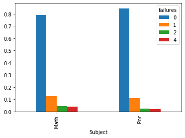

```python
pd.crosstab(data['Subject'], data['failures'], normalize = 'index').plot.bar()
```

Ответ: математики

- Сколько в среднем времени в неделю уходит на учебу по каждому предмету?

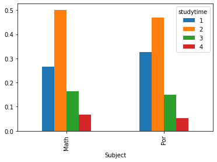

```python
pd.crosstab(data['Subject'], data['studytime'], normalize = 'index').plot.bar()
```

Ответ: от 2 до 5 часов, хотя у математиков в среднем уходит немного больше времени

- На что чаще обращают внимание при выборе школы?

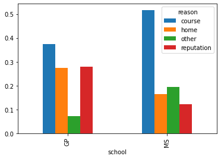

```python
pd.crosstab(data_single_duplicate['school'], data_single_duplicate['reason'], normalize = 'index').plot.bar()
```

Ответ: и там и там на course, хотя для GP home и reputation лишь незначительно отстают от course.

### Задание 4

Оцените распределение оценок (отдельно для `G1`, `G2` и `G3`). Сравните распределения для разных предметов - математики и португальского языка. Сделайте выводы.

**Tip:** Для выполнения задания пригодятся графики плотности, гистограммы и боксплоты.

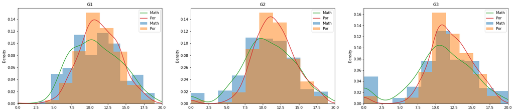

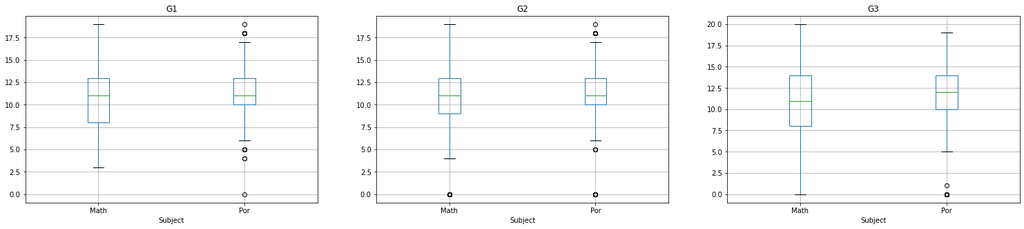

```python
fig, axes = plt.subplots(nrows=1, ncols=3, figsize=(25, 5))

data.groupby('Subject')['G1'].plot(kind='hist', alpha = 0.5, ax=axes[0], legend = True, xlim = [0,20], density=True, title='G1')
data.groupby('Subject')['G2'].plot(kind='hist', alpha = 0.5, ax=axes[1], legend = True, xlim = [0,20], density=True, title='G2')
data.groupby('Subject')['G3'].plot(kind='hist', alpha = 0.5, ax=axes[2], legend = True, xlim = [0,20], density=True, title='G3')

data.groupby('Subject')['G1'].plot(kind='kde', ax=axes[0], legend=True)
data.groupby('Subject')['G2'].plot(kind='kde', ax=axes[1], legend=True)
data.groupby('Subject')['G3'].plot(kind='kde', ax=axes[2], legend=True)

fig, axes = plt.subplots(nrows=1, ncols=3, figsize=(25, 5))
data.boxplot(column = 'G1', by = 'Subject', ax=axes[0])
plt.suptitle('')
data.boxplot(column = 'G2', by = 'Subject', ax=axes[1])
plt.suptitle('')
data.boxplot(column = 'G3', by = 'Subject', ax=axes[2])
plt.suptitle('')
```

Вывод: И на том и на другом курсе студенты учатся примерно одинаково, однако в среднем оценки по португальскому языку чуть выше чем по математике. Также нужно отметить, что среди заваливших G2 и G3 < 7 намного больше учащихся математике, чем португальскому. Однако во всех случаях интерквартильный рахмах и длина усов больше у математиков, что говорит о более плавном распределение оценок.

### Задание 5

Оцените попарные зависимости числовых признаков.  
Рассчитайте и провизуализируйте матрицу корреляций. Дайте содержательный комментарий.

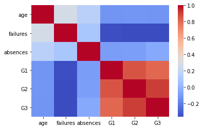

```python
corr = data.drop(columns ='combined_alc').select_dtypes(exclude=['bool','category']).drop('ID',axis=1).corr()
heatmap(corr, xticklabels=corr.columns, yticklabels=corr.columns, cmap='coolwarm')
```

На графике видно, что прямая корреляция наблюдается у оценок ( чем лучше оценка за предыдущие семестры - тем скорее всего будет лучше оценка за следующие ). Есть слабая прямая корреляция между возрастом и количеством завалов и пропусков. Также слабая обратная корреляция наблюдается у оценок и количеством завалов ( чем больше студент имеет завалов - тем хуже оценка )

### Задание 6

Оцените попарные зависимости нечисловых (категориальных) признаков, дайте содержательный комментарий.

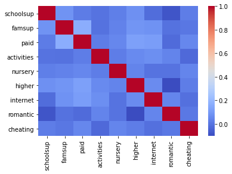

```python
corr = data.select_dtypes(include=['bool','category']).corr()
heatmap(corr, xticklabels=corr.columns, yticklabels=corr.columns, cmap='coolwarm')
```

Для категориальных признаков график показал, что все признаки практически независимы друг от друга (т.к их корреляция близка к 0). Однако, прослеживается слабая корреляция (~0.3 между признаками "получает помощь от семьи" и "записан на платные курсы")

### Задание 7

- Оцените, есть ли разница в употреблении алкоголя между парнями и девушками. Кто пьет больше?
- Оцените связь употребления алкоголя с признаками: address, Pstatus, higher, romantic, freetime.
- Оцените связь употребления алкоголя с уровнем образования опекуна (для случаев, где это известно).
- Сравните употребление алкоголя для 50 лучших учеников и 50 худших (по `G3`). Выполните сравнение отдельно для каждого предмета (`Math` и `Por`). Дайте содержательный комментарий.

**Tip:** для выполнения задания пригодятся боксплоты и гистограммы.

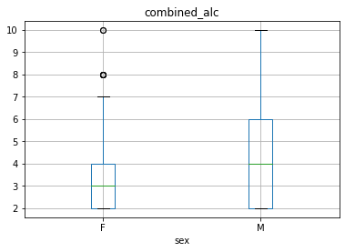

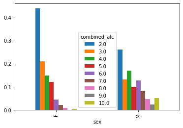

```python
#Оцените, есть ли разница в употреблении алкоголя между парнями и девушками. Кто пьет больше?
data_single_duplicate.boxplot(column = 'combined_alc', by = 'sex')
plt.suptitle('')
pd.crosstab(data_single_duplicate['sex'], data_single_duplicate['combined_alc'], normalize = 'index').plot.bar()
```

```python
#Оцените связь употребления алкоголя с признаками: address, Pstatus, higher, romantic, freetime.
```

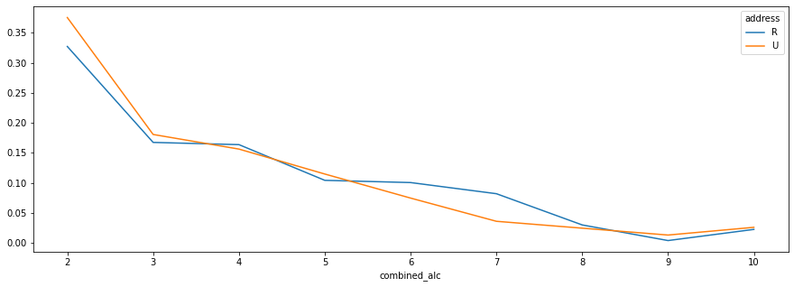

```python
pd.crosstab(data_single_duplicate['combined_alc'], data_single_duplicate['address'], normalize='columns').plot(figsize=(15,5))
```

Анализ графика не дает достаточных оснований сделать вывод о зависимости - линии примерно одинаковы

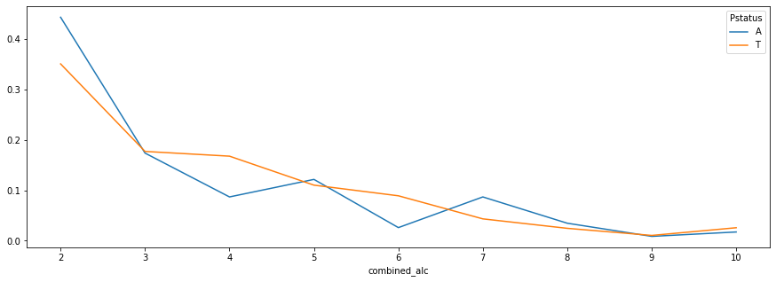

```python
pd.crosstab(data_single_duplicate['combined_alc'], data_single_duplicate['Pstatus'], normalize='columns').plot(figsize=(15,5))
```

Исходя из графиков сложно сделать однозначный вывод о зависимости. Можно предположить, что студенты, родители которых живут раздельно потребляют меньше алкоголя.

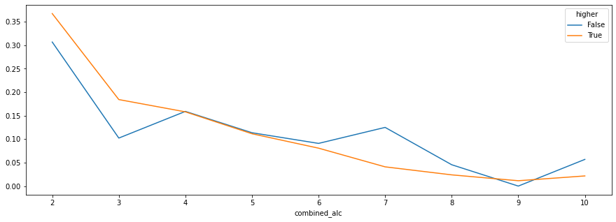

```python
pd.crosstab(data_single_duplicate['combined_alc'], data_single_duplicate['higher'], normalize='columns').plot(figsize=(15,5))
```

Исходя из графиков можно предположить, что студенты, которые не рассчитывают получать высшее образование в будущем потребляют больше алкоголя.

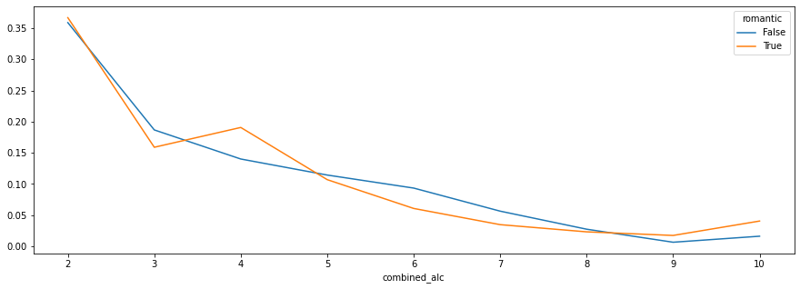

```python
pd.crosstab(data_single_duplicate['combined_alc'], data_single_duplicate['romantic'], normalize='columns').plot(figsize=(15,5))
```

Анализ графика не дает достаточных оснований сделать вывод о зависимости - линии примерно одинаковы

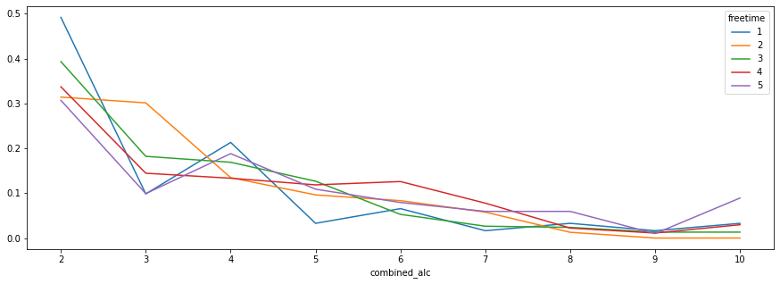

```python
pd.crosstab(data_single_duplicate['combined_alc'], data_single_duplicate['freetime'], normalize='columns').plot(figsize=(15,5))
```

Исходя из графика можно сделать вывод - с ростом свободного времени увеличивается количество потребляемого алкоголя, и наоборот - с уменьшением свободного времени уменьшается потребление. Это вытекает из того факта, что на маленьких значениях большую относительную частоту имеют freetime = 1,2, а на больших значениях потребления алкоголя - 4,5

- Оцените связь употребления алкоголя с уровнем образования опекуна (для случаев, где это известно).

```
3
```

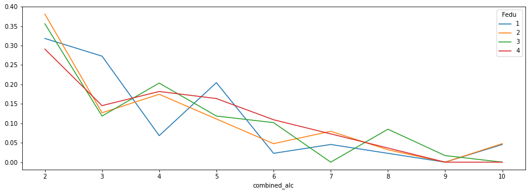

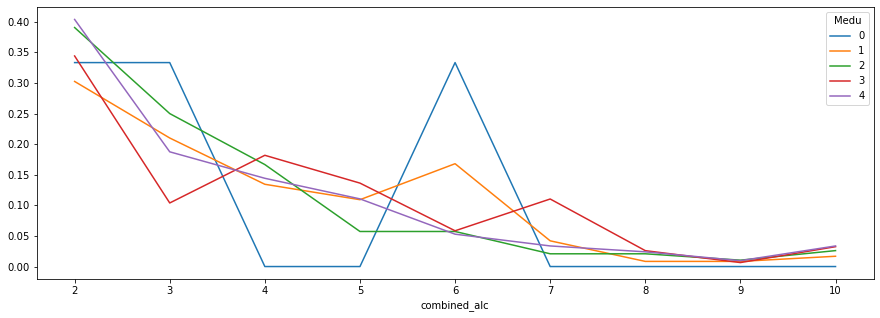

```python
gf = data_single_duplicate[data_single_duplicate['guardian']=='father']
pd.crosstab(gf['combined_alc'], gf['Fedu'], normalize='columns').plot(figsize=(15,5))

gm = data_single_duplicate[data_single_duplicate['guardian']=='mother']
pd.crosstab(gm['combined_alc'], gm['Medu'], normalize='columns').plot(figsize=(15,5))

print(len(gm[gm['Medu'] == '0']))
```

- Сравните употребление алкоголя для 50 лучших учеников и 50 худших (по G3).
- Выполните сравнение отдельно для каждого предмета (Math и Por).

```python
# отфильтровываем уникальных (учитываем 1 раз) тк. они могут повлиять на оценку
tmp = pd.concat([data_single_duplicate['Subject'], data_single_duplicate['G3'], data_single_duplicate['combined_alc']], axis=1).sort_values('G3', ascending=False)
```

```python
tmp[:50]['combined_alc'].mean()
```

```
3.0
```

```python
tmp[-50:]['combined_alc'].mean()
```

```
3.8
```

Видно, что топ 50 с конца пьют почти на 1 балл больше чем топ 50 с начала

Далее дубликаты будут нужны

```python
tmp = pd.concat([data['Subject'], data['G3'], data['combined_alc']], axis=1).sort_values('G3', ascending=False)
```

```python
tmp[tmp['Subject'] == 'Math'][['G3','combined_alc']][:50].corr()
```

|  | G3 | combined_alc |
| --- | --- | --- |
| G3 | 1.000000 | -0.235321 |
| combined_alc | -0.235321 | 1.000000 |

```python
tmp[tmp['Subject'] == 'Math'][['G3','combined_alc']][-50:].corr()
```

|  | G3 | combined_alc |
| --- | --- | --- |
| G3 | 1.000000 | 0.313022 |
| combined_alc | 0.313022 | 1.000000 |

```python
tmp[tmp['Subject'] == 'Por'][['G3','combined_alc']][:50].corr()
```

|  | G3 | combined_alc |
| --- | --- | --- |
| G3 | 1.000000 | -0.066011 |
| combined_alc | -0.066011 | 1.000000 |

```python
tmp[tmp['Subject'] == 'Por'][['G3','combined_alc']][-50:].corr()
```

|  | G3 | combined_alc |
| --- | --- | --- |
| G3 | 1.000000 | -0.123589 |
| combined_alc | -0.123589 | 1.000000 |

Исходя из полученных результатов можно увидеть, что для португальского зависимость оценки от потребления алкоголя практически отсутствует и для топ 50 сначала и с конца. Однако, наблюдается слабая зависимость у математиков - для топ 50 - обратная зависимость, для последних 50 - прямая, что, однако, странно (чем лучше оценка - тем больше количество выпитого алкоголя). Предполагаю, что она не состоятельна, так как только 12 человек из 50 имели оценки != 0, а значит - выборка слишком мала для каких-либо предположений.

### Задание 8

Оцените зависимость итоговой оценки от следующих признаков:

- Пола
- Времени в пути от дома до школы
- Наличия дополнительной помощи в учебе (от членов семьи или вообще)
- Посещения платных дополнительных занятий
- Наличия интернета
- Наличия романтических отношений
- Употребления алкоголя

```python
#print(pd.crosstab(data['G3'], data[['famsup','schoolsup']].sum(axis=1).rename('combined_sup'))
font_size = 20
rc('font', size=font_size)
rc('axes', titlesize=font_size)
```

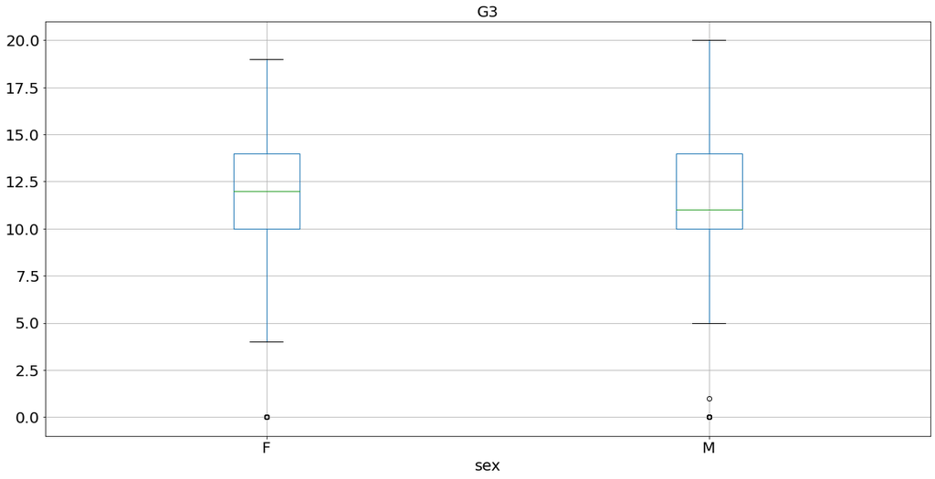

```python
data.boxplot(column = 'G3', by = 'sex', figsize=(20,10))
plt.suptitle('')
```

Вывод: несмотря на примерно одинаковый интерквартильный размах, девочки в среднем учатся ~ на 12 баллов, а мальчики в среднем учатся на 11, но среди них больше отличников чем у девочек.

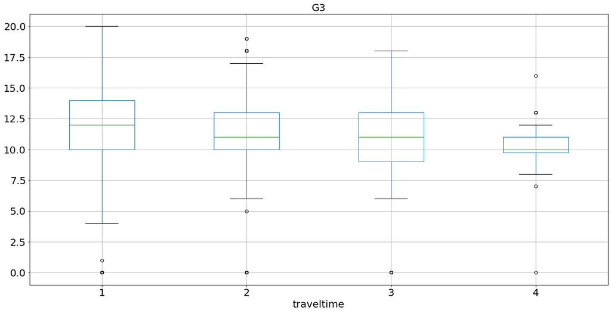

```python
data.boxplot(column = 'G3', by = 'traveltime', figsize=(20,10))
plt.suptitle('')
```

Вывод: наблюдается обратная зависимость - чем больше человек тратит времени на путь, тем хуже его оценка

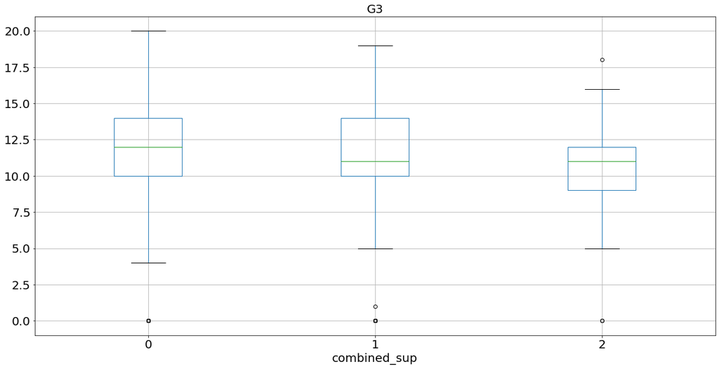

```python
data['combined_sup'] = data[['famsup','schoolsup']].sum(axis=1)
data.boxplot(column = 'G3', by = 'combined_sup', figsize=(20,10))
plt.suptitle('')
```

Вывод: наблюдается слабая обратная зависимость - чем человеку помогают, тем хуже его оценка

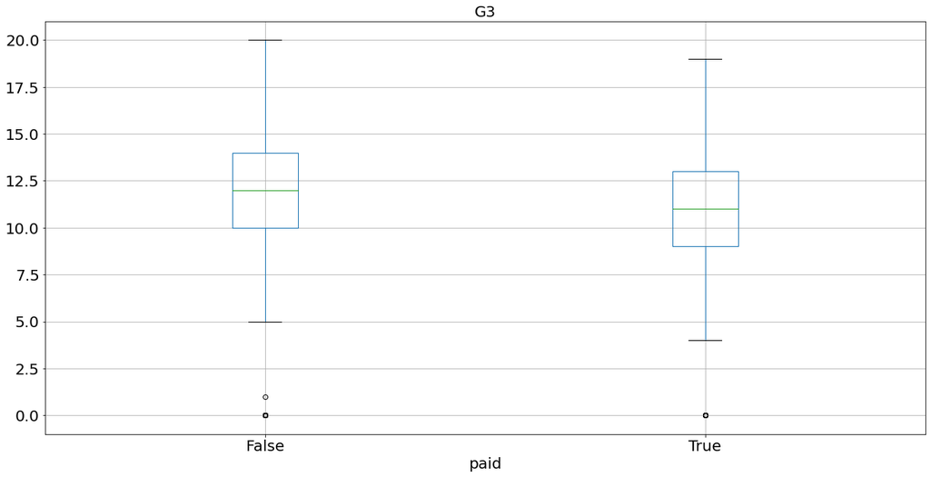

```python
data.boxplot(column = 'G3', by = 'paid', figsize=(20,10))
plt.suptitle('')
```

Вывод: Зависимости практически нет, люди, которые ходят на платные курсы чуть хуже занимаются (странно)

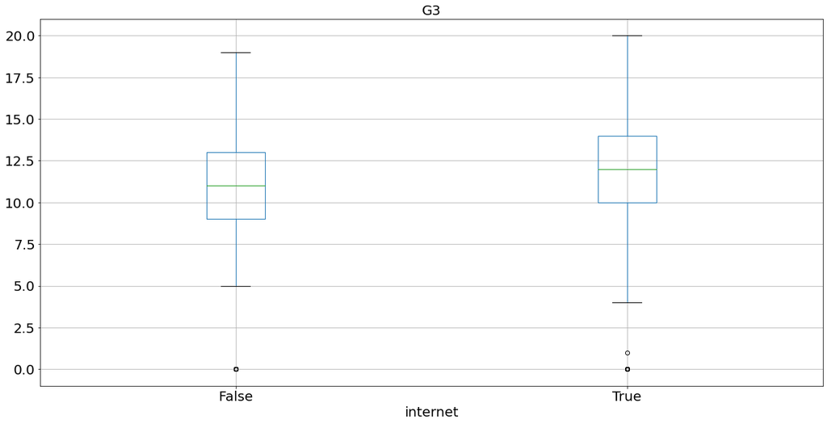

```python
data.boxplot(column = 'G3', by = 'internet', figsize=(20,10))
plt.suptitle('')
```

Вывод: наблюдается прямая зависимость - студенты, у которых есть интернет лучше учатся.

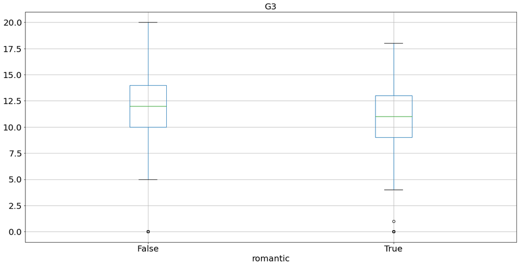

```python
data.boxplot(column = 'G3', by = 'romantic', figsize=(20,10))
plt.suptitle('')
```

Вывод: Зависимости практически нет, студенты, имеющие пару чуть хуже учатся

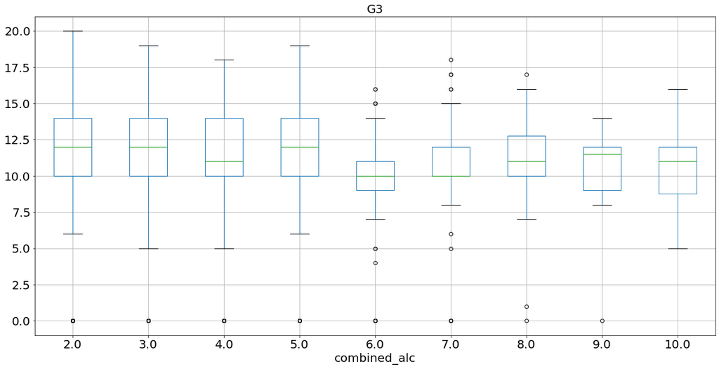

```python
data.boxplot(column = 'G3', by = 'combined_alc', figsize=(20,10))
plt.suptitle('')
```

Вывод: итоговая оценка зависит от количества потребляемого алкоголя - чем меньше потребление, тем лучше оценка ( видно по верхнему квартилю и медиане), хотя те, кто потребляет 8-10 учатся в среднем не намного хуже чем их малопьющие однокурсники.

### Задание 9

Добавьте в данные новый признак - итоговая оценка по 4-х балльной шкале:

- Отлично: 18 <= `G3` <= 20
- Хорошо: 14 <= `G3` <= 17
- Удовлетворительно: 8 <= `G3` <= 13
- Неудовлетворительно: `G3` < 8

Оцените распределение нового признака в зависимости от признака `reason` (причина выбора школы). Дайте содержательный комментарий.

```python
def new_mark_system(mark):
    if 18<=mark<=20:
        return 3
    elif 14<=mark<=17:
        return 2
    elif 8<=mark<=13:
        return 1
    else:
        return 0

data = data.assign(new_score_sys = data['G3'].apply(new_mark_system))
```

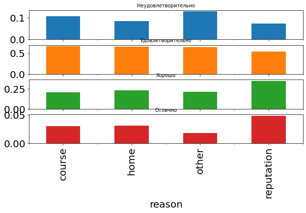

```python
rc('axes', titlesize=10)
ax = pd.crosstab(data['reason'],data['new_score_sys'], normalize = 'index').plot(kind = 'bar', figsize = [10,5], subplots=True, legend=False)
ax[0].set_title('Неудовлетворительно')
ax[1].set_title('Удовлетворительно')
ax[2].set_title('Хорошо')
ax[3].set_title('Отлично')
```

Вывод: Студенты, которые выбрали школу из-за репутации учатся лучше других. Хуже всего учатся студенты, выбравшие другие причины.

### Задание 11

Предложите простую модель для определения (предсказания) итоговой оценки студента по 4-х балльной системе. Оцените точность предложенной модели.

```python
c_data = 750
```

```python
from sklearn.preprocessing import OneHotEncoder, LabelEncoder
from sklearn.compose import ColumnTransformer
from sklearn.tree import DecisionTreeClassifier
from sklearn.preprocessing import OneHotEncoder, LabelEncoder
not_ord = ['Pstatus','address', 'sex', 'school', 'Subject','Mjob','Fjob','reason','guardian']
```

```python
def guesser(xData, c_data):
    model = DecisionTreeClassifier()

    le = LabelEncoder()
    for col in xData:
        xData[col] = le.fit_transform(xData.loc[:,col])

    ct = ColumnTransformer([("Geography", OneHotEncoder(), not_ord)], remainder = 'passthrough')
    xData = ct.fit_transform(xData)

    model.fit(xData[:c_data], data['new_score_sys'][:c_data])

    t = 0
    f = 0
    for i, true_score in enumerate(data['new_score_sys'][c_data:]):
        p = model.predict(np.array(xData[c_data + i]).reshape(1, -1))[0]
        if p == true_score:
            t+=1
        else:
            f+=1

    return t/(t+f), model
```

```python
xData = data.drop(columns=['ID','G3','combined_sup','combined_alc','new_score_sys'])
prob,_ = guesser(xData,c_data)
print('Вероятность правильного угадывания при известных G1 G2: {0:.2f}%'.format(prob * 100))

xData = xData.drop(columns='G2')
prob, _ = guesser(xData,c_data)
print('Вероятность правильного угадывания при известном G1: {0:.2f}%'.format(prob * 100))

xData = xData.drop(columns='G1')
prob, model = guesser(xData,c_data)
print('Вероятность правильного угадывания при неизвестных оценках: {0:.2f}%'.format(prob * 100))
```

```
Вероятность правильного угадывания при известных G1 G2: 78.57%
Вероятность правильного угадывания при известном G1: 72.79%
Вероятность правильного угадывания при неизвестных оценках: 58.50%
```

Вывод: Система была обучена на 70% данных и протестирована на 30%. Результат вышел достаточным, чтобы делать предположения

### Задание * (бонусное)

Дополнительное исследование данных и выводы положительно скажутся на оценке.

Просто красивое дерево, предполагается что у вас экран размером как в кинотеатре.

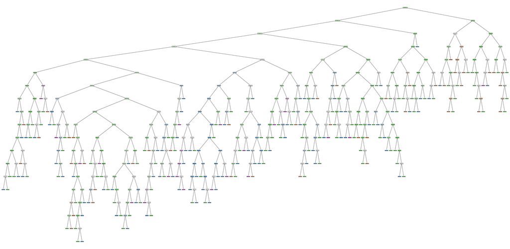

```python
from sklearn.tree import plot_tree
plt.figure(figsize = (60,30))
plot_tree(model, filled=True)
plt.show()
```